# Lecture 07 — Differential Abundance: Do Cell-Type Proportions Change?

Bill Cresko

# Lecture 07: Differential Abundance

## Where this lecture fits

- Previous: Lec 06 — Functional Analysis
- **You are here:** Lec 07 — *the compositional complement to differential expression*
- Next: Lec 08 — Reference-based Annotation
- **Companion tutorial:** Tutorial 07 — Differential Abundance with miloR
- **Parallel reading:** [scNotebooks Module 04 (differential abundance section)](https://integrativebioinformatics.github.io/scNotebooks/modules/en/module04/module04.html)

## Goals of this lecture

- See **why** differential abundance is a different question from differential expression
- Understand the limits of cluster-level proportion tests
- Read the **miloR** algorithm — neighbourhoods on a kNN graph + per-neighbourhood NB GLM + **SpatialFDR**
- Read the signature miloR plots (neighbourhood graph, beeswarm)
- Avoid common mistakes: pseudo-replicates, cluster-boundary artifacts, condition imbalance

# The two questions, side by side

## Compositional analysis — overview

[figure not shown]

Compositional analysis — what shifts in cell-type proportions look like

- The **composition** of cell types in a sample is itself a measurement
- A condition can change the **mix of types** even when within-type expression is unchanged
- This lecture covers the statistical machinery for testing those proportion shifts

## Compositional analysis — overview (dup1)

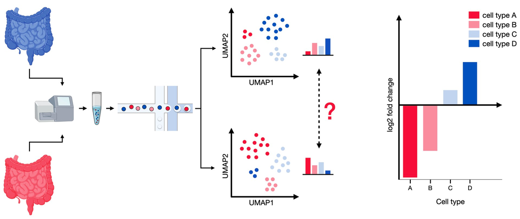

Compositional — raster reference

## Differential expression vs differential abundance

|  | Differential Expression (Lec 04) | Differential Abundance (Lec 07) |
| --- | --- | --- |
| Question | For cells of the same type, **which genes change** between conditions? | Do **cell-type proportions** themselves change between conditions? |
| Tool | `DESeq2` on pseudobulk | `miloR` on kNN neighbourhoods |
| Unit of test | Per gene, per cell type | Per neighbourhood (a small group of similar cells) |
| Statistical test | Negative binomial GLM on counts | Negative binomial GLM on cell counts per neighbourhood |
| Output | per-gene log2FC + padj | per-neighbourhood log2FC + SpatialFDR |

**Note**

**They are complementary, not redundant.** A perturbation can change cell-type proportions, gene expression within types, both, or neither. A complete condition-level analysis reports both.

## A toy example — same dataset, four possible patterns

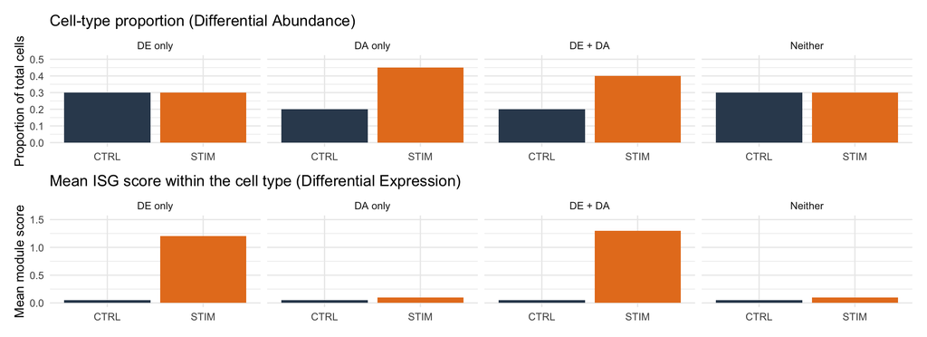

- **DE only** — same cell-type proportion, but every cell shifts expression. Common pattern for IFN-β–stimulated mature cells.
- **DA only** — proportion shifts, but each cell of the type has the same expression profile. Common pattern for cell-cycle expansion or recruitment.
- **DE + DA** — both move. Common in disease vs healthy.
- **Neither** — no change. The null.

# The naive approach — and why it fails

## Cluster-level Fisher’s exact

The simple thing to do is: count cells per (cluster, sample), make a 2×2 table per cluster (cluster × condition), run Fisher’s exact / chi-squared.

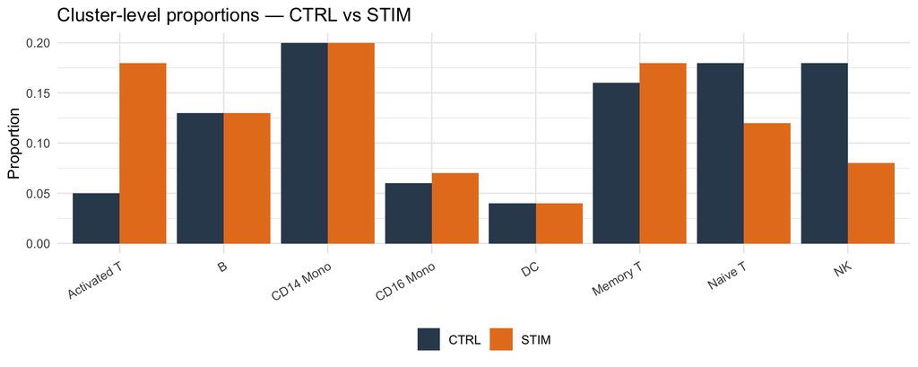

This works for big, well-separated clusters but breaks in three ways:

1. **Hard cluster boundaries are arbitrary.** A cell type that spans two clusters at one resolution and one cluster at another gives a different test result.
2. **Within-cluster heterogeneity is invisible.** A cluster of “T cells” that contains both expanding-activated and shrinking-naive populations will show NO net change at the cluster level — but real DA at finer resolution.
3. **Cells aren’t independent samples.** Per-cell counting treats every cell as a replicate; the right unit is the donor / sample.

**Warning**

**The naive cluster-level Fisher test is the most common mistake in scRNA-seq DA.** It’s anti-conservative (cell counts inflate the effective sample size) and resolution-dependent. Use miloR instead.

# How miloR works

## The five-step algorithm

1. Build the **kNN graph** on the integrated PC reduction (the same one you use for clustering)
2. Define **overlapping neighbourhoods** — each neighbourhood is a representative cell + its k nearest neighbours; sample ~1000 neighbourhoods total
3. **Count cells per neighbourhood per sample** (one row per donor × condition × neighbourhood)
4. Fit a **negative-binomial GLM** per neighbourhood with your design (`~ condition`, optionally `+ donor`) — gets a log2FC per neighbourhood
5. Apply **SpatialFDR** correction across overlapping neighbourhoods (a weighted BH that accounts for the correlation between adjacent tests)

## Why neighbourhoods, not clusters?

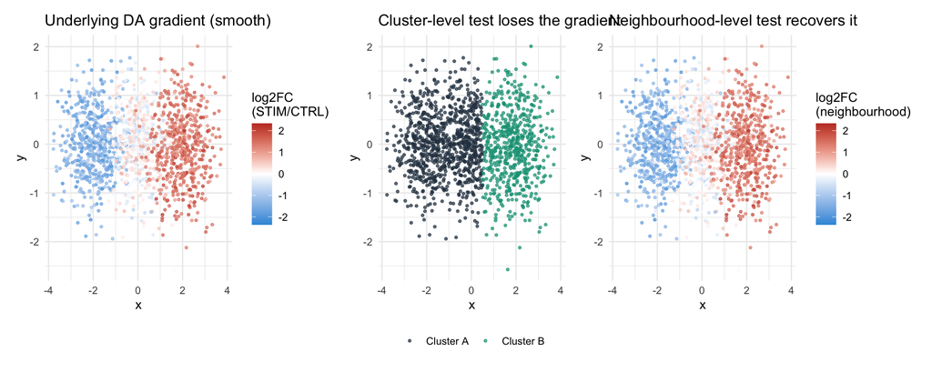

The middle panel shows what cluster-level DA “sees” — two homogeneous groups. The right panel is what miloR’s neighbourhood-level test recovers — the smooth gradient that’s actually there.

## The neighbourhood graph (signature miloR plot)

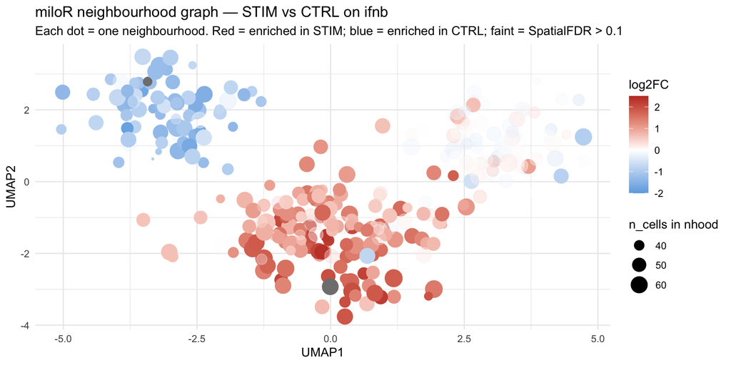

## The beeswarm — DA per cell type

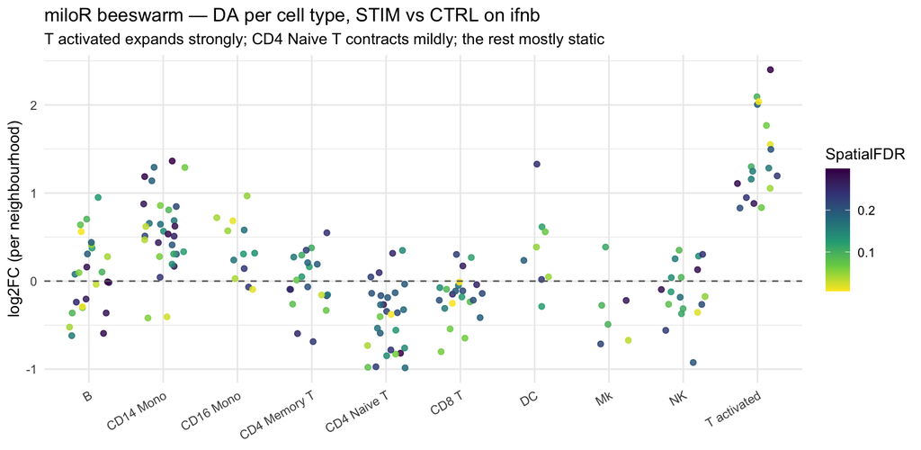

**Tip**

**Read the beeswarm vertically.** A cell type with most points above zero is **enriched** in STIM; below zero, **depleted**. A cell type with points scattered above AND below zero contains both expanding and contracting subpopulations — the case where neighbourhood-level testing recovers what cluster-level testing would miss.

# Practical considerations

## How many neighbourhoods? How many cells per neighbourhood?

- `prop = 0.1` (sample 10% of cells as neighbourhood centres) is the default and works for most datasets in the 5k–50k range
- Aim for the median neighbourhood size around **50–200 cells**. Too small (<30) → underpowered; too large (>500) → spatial smoothing that loses fine structure
- `plotNhoodSizeHist(milo)` is the go-to diagnostic — peak between 50 and 200 means you’re set
- If your peak is too small, increase `k` (graph k-nearest-neighbours) from 30 → 50 or 75

## Replication — the same rule as DESeq2

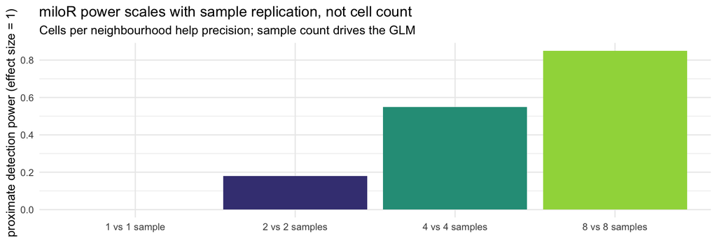

**Warning**

**No replication, no inference.** A 1-vs-1 sample comparison gives miloR no degrees of freedom; you’ll get NA p-values everywhere. Plan for 4 vs 4 minimum if you want any chance of detecting modest effects.

## Designs that work well

| Design | Notes |
| --- | --- |
| `~ condition` | Two-condition contrast, no other covariates |
| `~ donor + condition` | Paired design (donors balanced across conditions) — preferred when you have it |
| `~ batch + condition` | Block on batch effects |
| `~ severity` | Continuous covariate (e.g. clinical severity score) |
| `~ donor + group + condition + group:condition` | Interaction tests |

The full DESeq2-style design framework is available — including interactions, continuous covariates, and random-effect-style blocking.

# Pitfalls

## Five mistakes worth knowing

1. **Running on the unintegrated kNN graph.** If batch effect dominates the embedding, neighbourhoods cluster by sample, and DA falsely “detects” composition shifts that are really batch artifacts. Always run miloR on the **integrated** reduction.
2. **Synthetic donor splits passed as biological replicates.** Splitting one large library into “pseudo-donors” gives miloR fake degrees of freedom — the test is anti-conservative. The workshop tutorial flags this with a `set.seed(2026)` synthetic split for illustration only; never report those p-values as real findings.
3. **Imbalanced sample sizes.** 8 STIM vs 1 CTRL gives almost no information about the CTRL distribution. Aim for balanced designs.
4. **Ignoring `seurat_annotations` mapping.** Without `annotateNhoods()`, you’ll get neighbourhood-level results but no easy way to summarise by cell type. Always run `annotateNhoods` after `testNhoods`.
5. **Reading the UMAP without the SpatialFDR filter.** A red cluster of dots that all have SpatialFDR > 0.5 is just visual noise. Filter `da_results$SpatialFDR < 0.1` before drawing conclusions.

# Recap & what’s next

## What to remember from Lecture 07

- **DE asks “which genes change?”; DA asks “do proportions change?”** — independent questions, both worth running
- Cluster-level DA tests are anti-conservative and resolution-dependent — **don’t use them**
- `miloR` works at the **neighbourhood level** on the integrated kNN graph, with NB GLM + SpatialFDR
- Read DA results with the **neighbourhood graph** (spatial pattern) and the **beeswarm** (per cell type)
- Need replication — at minimum 4 vs 4 biological replicates, ideally with paired donors
- Always run miloR on the **integrated** reduction, not the unintegrated PCA

## Further reading

- Dann *et al.* 2022, *Nat Biotechnol* — miloR paper, [doi:10.1038/s41587-021-01033-z](https://doi.org/10.1038/s41587-021-01033-z)
- Büttner *et al.* 2021 — *scCODA*, a Bayesian compositional alternative, [doi:10.1038/s41467-021-27150-6](https://doi.org/10.1038/s41467-021-27150-6)
- Phipson *et al.* 2022 — *propeller*, fast linear-model-based DA, [doi:10.1093/bioinformatics/btac582](https://doi.org/10.1093/bioinformatics/btac582)
- [scNotebooks Module 04 (DA section)](https://integrativebioinformatics.github.io/scNotebooks/modules/en/module04/module04.html)